# Gráficos Finais e Sumário

### Primeiro Gráfico

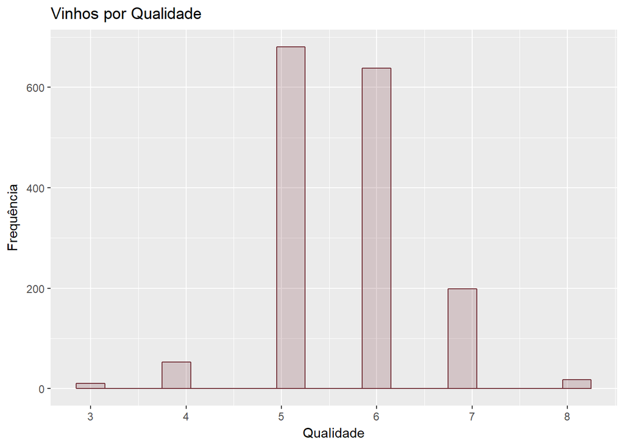

### Descrição do Primeiro Gráfico

A distribuição da qualidade dos vinhos no conjunto de dados.  
Há muito mais observações de vinhos medianos, do que de vinhos inferiores e melhores.

### Segundo Gráfico

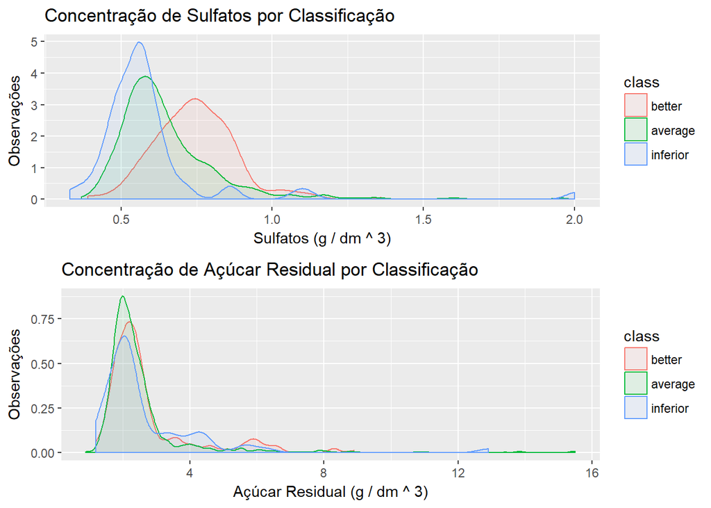

### Descrição do Segundo Gráfico

Curiosamente sulfatos tem maior influência do que o açúcar residual.  
Enquanto grande parte dos vinhos tem concentrações semelhantes de açúcar, os vinhos considerados melhores tem maior concentração de sulfatos.

### Terceiro Gráfico

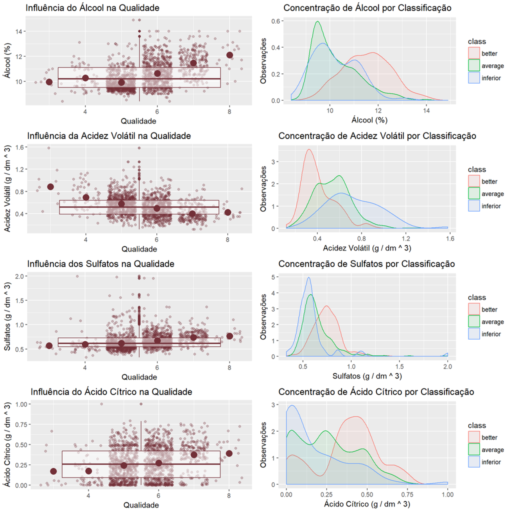

### Descrição do Terceiro Gráfico

Uma visão geral dos quatro atributos que possivelmente mais influenciaram na percepção dos profissionais que avaliaram a qualidade dos vinhos neste conjunto de dados.

# Reflexão

Os dados sugerem o Álcool, Acidez Volátil, Sulfatos e Ácido Cítrico, como sendo os possíveis atributos indicativos de qualidade para os vinhos.

Mas neste conjunto de dados, a quantidade de vinhos na categoria mediana está acima de 80%, com 3% de vinhos inferiores e 13% de vínhos considerados melhores.

Um conjunto de dados com melhor distribuição seria interessante para afinar um modelo preditivo mais acurado.

Futuramente seria interessante contar com a ajuda de alguém com formação na área de química. Talvez novos insights surjam sobre esta base de dados ou sugestões para criação de um novo conjunto de dados, com mais variáveis quimicamente importantes e que talvez não tenham sido incluídas no conjunto de dados atual.

Considerei bastante instrutivo trabalhar nesta análise, que me proporcionou vivenciar um pouco mais do que a ciência de dados pode nos oferecer.

Durante este projeto e anteriores, brotaram e minha mente idéias que reservo para explorar futuramente. Com a satisfação de compreender melhor as ferramentas necessárias para isso.

#### Referências conforme solicitadas pelo autores do conjunto de dados.

P. Cortez, A. Cerdeira, F. Almeida, T. Matos e J. Reis. Modelagem de preferências de vinhos por mineração de dados a partir de propriedades físico-químicas. Em Decision Support Systems, Elsevier, 47 (4): 547-553. ISSN: 0167-9236.

Disponível em: [@Elsevier] http://dx.doi.org/10.1016/j.dss.2009.05.016  
[Pré-impressão (pdf)] http://www3.dsi.uminho.pt/pcortez/winequality09.pdf  
[bib] http://www3.dsi.uminho.pt/pcortez/dss09.bib